# Project_3_ShubhamTomar

2022-10-09

```r
library(tidyverse)
library(dplyr)
library(lubridate)
library(stringr)
```

```r
b_lyrics <- readr::read_csv('https://raw.githubusercontent.com/rfordatascience/tidytuesday/master/data/2020/2020-09-29/beyonce_lyrics.csv')
ts_lyrics <- readr::read_csv('https://raw.githubusercontent.com/rfordatascience/tidytuesday/master/data/2020/2020-09-29/taylor_swift_lyrics.csv')
sales <- readr::read_csv('https://raw.githubusercontent.com/rfordatascience/tidytuesday/master/data/2020/2020-09-29/sales.csv')
```

#Part 1: Explore album sales

##Part 1A: Data wrangling

```r
sales_1 <- sales %>%
   mutate(released = str_remove(released, "\\(.*"))

x<- mdy(sales_1$released)

sales_1 <- sales_1 %>%
  mutate(released = x)

sales_2 <- sales_1 %>%
  mutate(country = fct_collapse(sales_1$country, "FR"= c("FRA", "FR"), "World"= c("WW", "World"))) %>%
  group_by(country) %>%
  filter(country %in% c("US", "UK", "World"))

sales_2[c("sales")] <- sales_2[c("sales")]/1e6

sales_2
```

```
## # A tibble: 36 × 8
## # Groups:   country [3]
##    artist       title        country  sales released   re_release  label formats
##    <chr>        <chr>        <fct>    <dbl> <date>     <chr>       <chr> <chr>
##  1 Taylor Swift Taylor Swift US       5.72  2006-10-24 March 18, … Big … CD, CD…
##  2 Taylor Swift Fearless     World   12     2008-11-11 October 27… Big … CD, CD…
##  3 Taylor Swift Fearless     US       7.18  2008-11-11 October 27… Big … CD, CD…
##  4 Taylor Swift Fearless     UK       0.609 2008-11-11 October 27… Big … CD, CD…
##  5 Taylor Swift Speak Now    World    5     2010-10-25 <NA>        Big … CD, CD…
##  6 Taylor Swift Speak Now    US       4.69  2010-10-25 <NA>        Big … CD, CD…
##  7 Taylor Swift Speak Now    UK       0.169 2010-10-25 <NA>        Big … CD, CD…
##  8 Taylor Swift Red          World    6     2012-10-22 <NA>        Big … CD, CD…
##  9 Taylor Swift Red          US       4.46  2012-10-22 <NA>        Big … CD, CD…
## 10 Taylor Swift Red          UK       0.693 2012-10-22 <NA>        Big … CD, CD…
## # … with 26 more rows
```

##Part 1B: Only US Albums

```r
sales_3 <- sales_2 %>% group_by(country) %>%
  filter(country %in% c("US"))

release_date <- sales_3$released
today <- ymd(20221013)
interval(release_date, today)
```

```
##  [1] 2006-10-24 UTC--2022-10-13 UTC 2008-11-11 UTC--2022-10-13 UTC
##  [3] 2010-10-25 UTC--2022-10-13 UTC 2012-10-22 UTC--2022-10-13 UTC
##  [5] 2014-10-27 UTC--2022-10-13 UTC 2017-11-10 UTC--2022-10-13 UTC
##  [7] 2019-08-23 UTC--2022-10-13 UTC 2003-06-23 UTC--2022-10-13 UTC
##  [9] 2006-09-01 UTC--2022-10-13 UTC 2008-11-14 UTC--2022-10-13 UTC
## [11] 2011-06-24 UTC--2022-10-13 UTC 2013-12-13 UTC--2022-10-13 UTC
## [13] 2016-04-23 UTC--2022-10-13 UTC
```

```r
years_since_release <- interval(release_date, today) %>%
  as.numeric('years') %>%
  round(digits = 0)

sales_4 <- sales_3 %>% mutate(years_since_release)

sales_4 %>%
  summarise(years_since_release, median = median(years_since_release), oldest = max(years_since_release), newest= min(years_since_release))
```

```
## # A tibble: 13 × 5
## # Groups:   country [1]
##    country years_since_release median oldest newest
##    <fct>                 <dbl>  <dbl>  <dbl>  <dbl>
##  1 US                       16     11     19      3
##  2 US                       14     11     19      3
##  3 US                       12     11     19      3
##  4 US                       10     11     19      3
##  5 US                        8     11     19      3
##  6 US                        5     11     19      3
##  7 US                        3     11     19      3
##  8 US                       19     11     19      3
##  9 US                       16     11     19      3
## 10 US                       14     11     19      3
## 11 US                       11     11     19      3
## 12 US                        9     11     19      3
## 13 US                        6     11     19      3
```

##Part 1C: Percent stacked barchart:

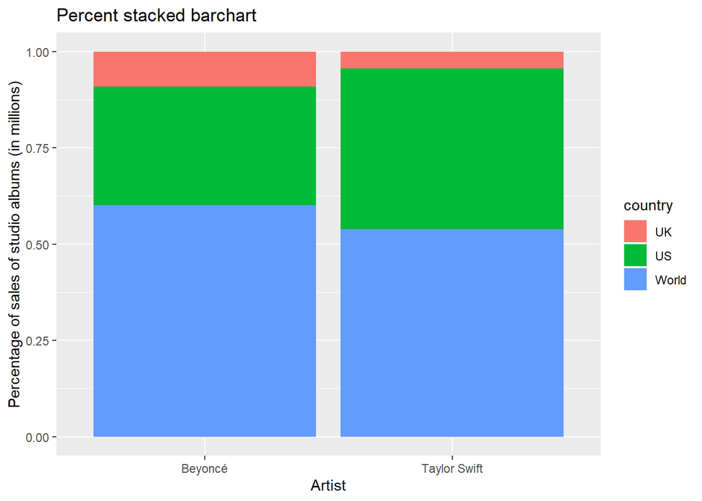

```r
library(dplyr)

graph_data <- sales_2 %>%
  group_by(artist, country) %>%
  summarise(TotalSales=sum(sales))
library(ggplot2)
graph_data %>%
  ggplot(aes(fill= country ,y= TotalSales, x= artist)) +
  geom_bar(position="fill", stat="identity") +
  labs(title = "Percent stacked barchart", x= "Artist", y= "Percentage of sales of studio albums (in millions)")
```

##Part 1D: Sales

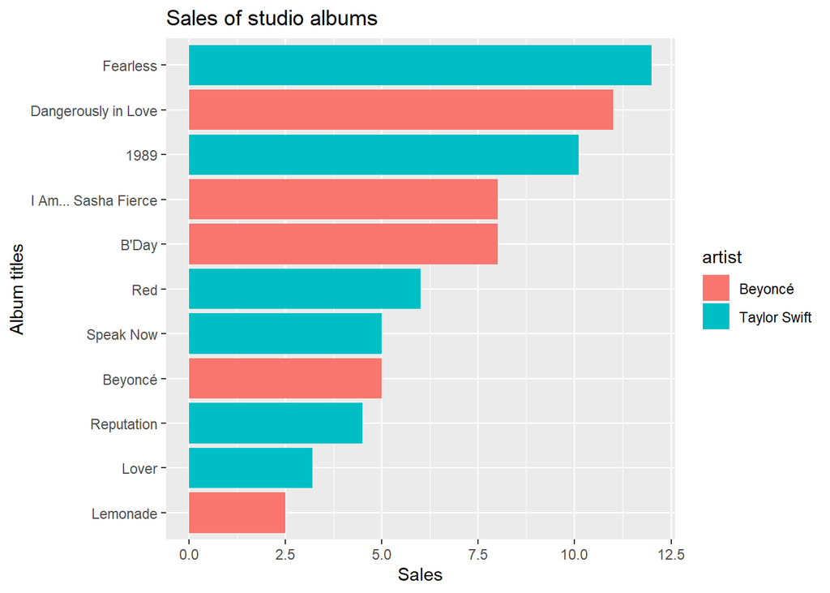

```r
sales_5 <- sales_2 %>%
           filter(country== 'World')

sales_5 %>%
  ggplot(aes(x= sales, y=fct_reorder(.f = title, .x =sales), fill= artist ))+
  geom_bar(stat = "identity") +
  labs(title = "Sales of studio albums", x= "Sales", y= "Album titles")
```

##Part 1E: Scatter plot

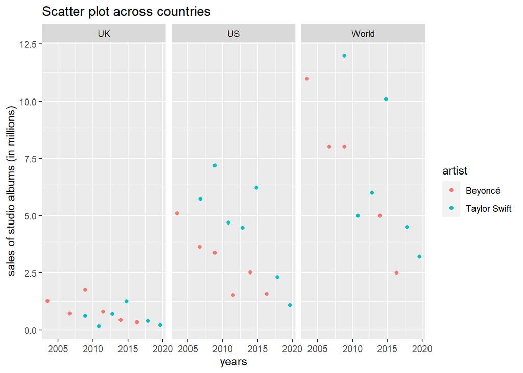

```r
scat_sale <- ggplot(sales_2, aes(x=released, y=sales, col=artist)) +
     geom_point()
scat_sale +
  facet_grid(. ~ country) +
  labs(title = "Scatter plot across countries", x= "years", y= "sales of studio albums (in millions)")
```

#Part 2: Exploring sentiment of lyrics

```r
library(tidytext)
```

###Part 2A: hello and goodbye Taylor

```r
ts_lyrics_token<-
  ts_lyrics %>%
     unnest_tokens(output = line,
                   input = Lyrics,
                   token = "lines") %>%
     mutate(linenumber = row_number())

hello_ts<- str_subset(ts_lyrics_token$line, "hello")
goodbye_ts <- str_subset(ts_lyrics_token$line, "goodbye")

hello_ts
```

```
## [1] "and say, \"hello\""                 "that i can't say \"hello\" to you"
## [3] "'cause all i know is we said hello" "'cause all i know is we said hello"
## [5] "all i know is we said hello"        "all i know is we said hello"
```

```r
summary(hello_ts)
```

```
##    Length     Class      Mode
##         6 character character
```

```r
goodbye_ts
```

```
##  [1] "goodbye, baby"
##  [2] "braced myself for the goodbye,"
##  [3] "you gave me all your love and all i gave you was goodbye"
##  [4] "and force us into a goodbye"
##  [5] "and risk another goodbye"
##  [6] "stumbled through the long goodbye"
##  [7] "but people like me are gone forever when you say goodbye"
##  [8] "said goodbye in "
##  [9] "said goodbye in "
## [10] "saying goodbye is death by a thousand cuts"
## [11] "'cause saying goodbye is death by a thousand cuts"
## [12] "i'll tell you truth, but never, \"goodbye\""
```

```r
summary(goodbye_ts)
```

```
##    Length     Class      Mode
##        12 character character
```

###Part 2B hello and goodbye Beyonce

```r
hello_b<- str_subset(b_lyrics$line, "hello")
goodbye_b<- str_subset(b_lyrics$line, "goodbye")

hello_b
```

```
##  [1] "Fellow great Americans, hello"
##  [2] "You had me at hello (Hello)"
##  [3] "You had me at hello (Hello)"
##  [4] "'Cause you had me at hello (My cool) (Hello)"
##  [5] "You had me at hello (Hello)"
##  [6] "You had me at hello (Hello)"
##  [7] "You had me at hello (Hello)"
##  [8] "Hello (Hello, hello)"
##  [9] "You had me at hello (Hello)"
## [10] "You had me at hello (Hello)"
## [11] "You had me at hello (Hello)"
## [12] "You had me at hello"
## [13] "You had me at hello (Hello)"
## [14] "You had me at hello (Hello)"
## [15] "'Cause you had me at hello (My cool) (Hello)"
```

[output cut: 17 more lines]

```r
summary(hello_b)
```

```
##    Length     Class      Mode
##        32 character character
```

```r
goodbye_b
```

```
##  [1] "We only said goodbye with words"
##  [2] "We only said goodbye with words"
##  [3] "We only said goodbye with words"
##  [4] "Thank God, I found the good in goodbye"
##  [5] "Thank God, I found the good in goodbye"
##  [6] "Thank God, I found the good in goodbye"
##  [7] "It's so hard to say goodbye"
##  [8] "I never want to say goodbye"
##  [9] "I never, ever want to say goodbye"
## [10] "We've got to say goodbye"
## [11] "Don't have to say goodbye"
## [12] "Somewhere between hi and goodbye, I felt so comfortable"
```

```r
summary(goodbye_b)
```

```
##    Length     Class      Mode
##        12 character character
```

###Part 2C b_lyrics dataset, barchart and Wordcloud

```r
b_lyrics_token <-
  b_lyrics %>%
     unnest_tokens(output = word,
                   input = line,
                   token = "words") %>%
  mutate(linenumber = row_number()) %>%
  anti_join(stop_words) %>%
  count(word, sort = TRUE) %>%
 inner_join(get_sentiments("bing"))
```

####sorting row from most frequent to least frequent, and filtering top 25 words

```r
b_lyrics_token<- arrange(b_lyrics_token, desc(n)) %>%
  head(b_lyrics_token, n=25)
b_lyrics_token
```

```
## # A tibble: 25 × 3
##    word          n sentiment
##    <chr>     <int> <chr>
##  1 love       1362 positive
##  2 crazy       308 negative
##  3 top         241 positive
##  4 bad         132 negative
##  5 beautiful   131 positive
##  6 whoa        121 positive
##  7 damn        106 negative
##  8 hurt         90 negative
##  9 hard         87 negative
## 10 ready        85 positive
## # … with 15 more rows
```

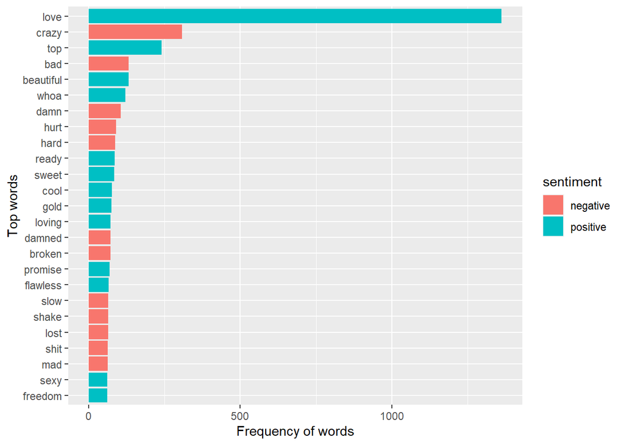

```r
b_lyrics_token %>%
  mutate(word = fct_reorder(word, n)) %>%
  ggplot(aes(x = n, y = word, fill= sentiment)) +
  geom_col(show.legend = TRUE) +
  labs(y= "Top words", x= "Frequency of words")
```

####WordCloud

```r
library(wordcloud)
library(RColorBrewer)
library(tm)
pal = brewer.pal(6, "RdGy")
```

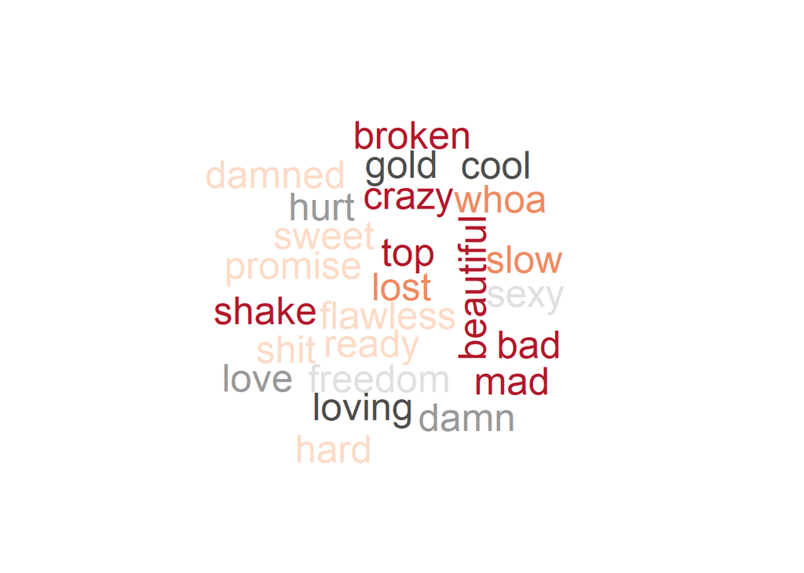

```r
b_lyrics_token %>%
  anti_join(stop_words) %>%
  count(word) %>%
  with(wordcloud(word, n, min.freq = 1, scale = c(2, 0.5), random.color = TRUE, colors = pal))
```

###Part 2D ts_lyrics dataset, barchart and Wordcloud

```r
ts_lyrics_wtoken <-
  ts_lyrics %>%
     unnest_tokens(output = word,
                   input = Lyrics,
                   token = "words") %>%
  mutate(linenumber = row_number()) %>%
  anti_join(stop_words) %>%
  count(word, sort = TRUE) %>%
 inner_join(get_sentiments("bing"))
```

####sorting row from most frequent to least frequent, and filtering top 25 words

```r
ts_lyrics_wtoken<- arrange(ts_lyrics_wtoken, desc(n)) %>%
  head(ts_lyrics_wtoken, n=25)
ts_lyrics_wtoken
```

```
## # A tibble: 25 × 3
##    word          n sentiment
##    <chr>     <int> <chr>
##  1 love        248 positive
##  2 bad          80 negative
##  3 shake        73 negative
##  4 break        59 negative
##  5 mad          48 negative
##  6 beautiful    46 positive
##  7 smile        45 positive
##  8 hate         44 negative
##  9 fall         43 negative
## 10 whoa         36 positive
## # … with 15 more rows
```

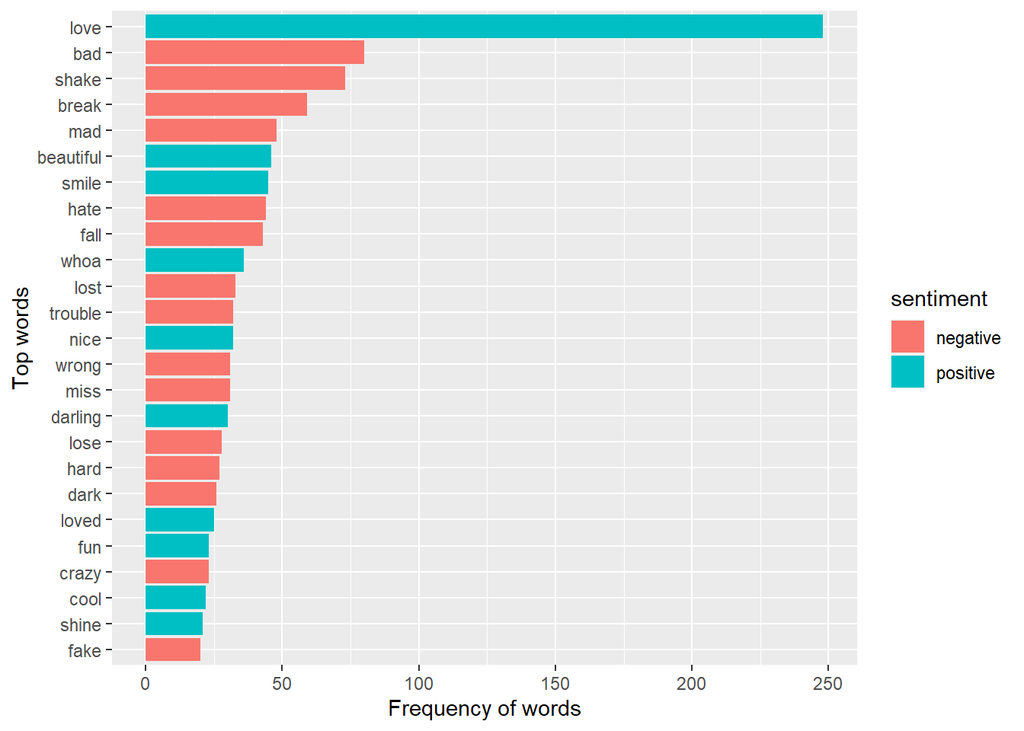

```r
ts_lyrics_wtoken %>%
  mutate(word = fct_reorder(word, n)) %>%
  ggplot(aes(x = n, y = word, fill= sentiment)) +
  geom_col(show.legend = TRUE) +
  labs(y= "Top words", x= "Frequency of words")
```

####WordCloud

```r
library(wordcloud)
library(RColorBrewer)
library(tm)
pal = brewer.pal(6, "RdGy")
```

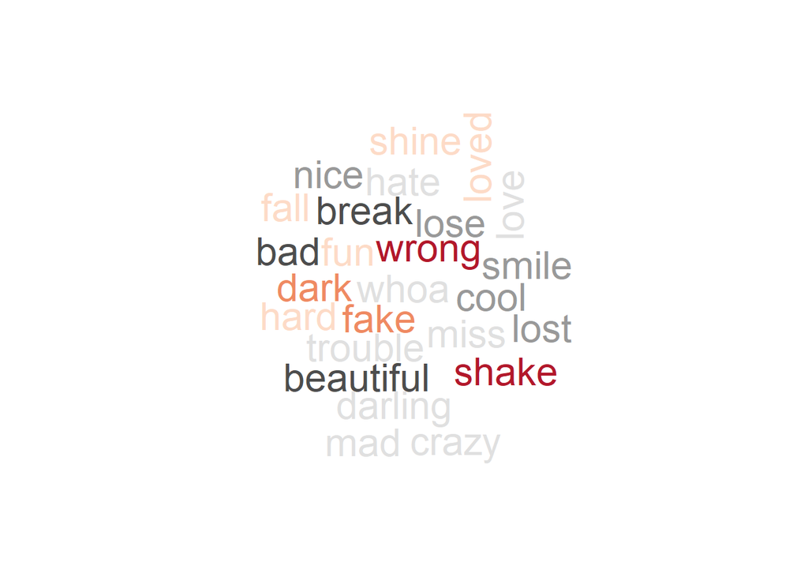

```r
ts_lyrics_wtoken %>%
  anti_join(stop_words) %>%
  count(word) %>%
  with(wordcloud(word, n, min.freq = 1, scale = c(2, 0.5), random.color = TRUE, colors = pal))
```

###Part 2E ts_lyrics_afinn

```r
get_sentiments("afinn")
```

```
## # A tibble: 2,477 × 2
##    word       value
##    <chr>      <dbl>
##  1 abandon       -2
##  2 abandoned     -2
##  3 abandons      -2
##  4 abducted      -2
##  5 abduction     -2
##  6 abductions    -2
##  7 abhor         -3
##  8 abhorred      -3
##  9 abhorrent     -3
## 10 abhors        -3
## # … with 2,467 more rows
```

```r
ts_lyrics_wtoken <-
  ts_lyrics %>%
     unnest_tokens(output = word,
                   input = Lyrics,
                   token = "words") %>%
  mutate(linenumber = row_number()) %>%
  anti_join(stop_words) %>%
  count(word, Album, sort = TRUE) %>%
  inner_join(get_sentiments("afinn")) %>%
  group_by(Album) %>%
  summarise(mean= mean(value))
ts_lyrics_wtoken
```

```
## # A tibble: 8 × 2
##   Album            mean
##   <chr>           <dbl>
## 1 1989         -0.822
## 2 Fearless      0.0192
## 3 folklore     -0.613
## 4 Lover        -0.429
## 5 Red          -0.00870
## 6 reputation   -0.495
## 7 Speak Now    -0.365
## 8 Taylor Swift  0.137
```

####Joining 2 datasets

```r
sales_2 <- sales_2 %>% rename_at("title", ~"Album")

ts_plot<- inner_join(x= sales_2,y= ts_lyrics_wtoken, by= "Album")
```

#### ggplot

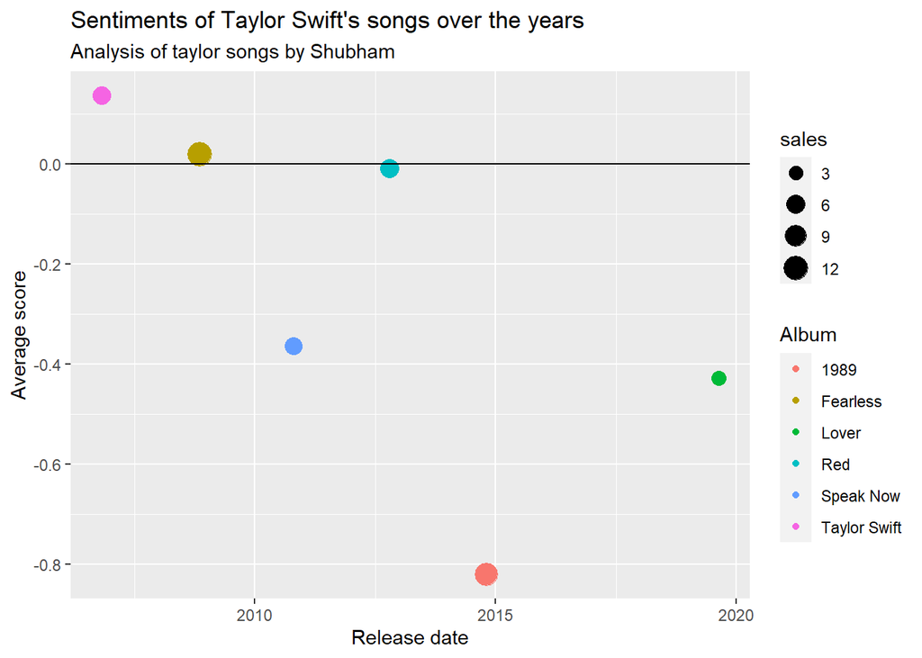

```r
ts_plot %>%
  ggplot(aes(x = released, y = mean, color= Album)) +
  geom_point(aes(size= sales)) +
  labs(title= "Sentiments of Taylor Swift's songs over the years" ,subtitle= "Analysis of taylor songs by Shubham" ,x= "Release date", y= "Average score") +
  geom_hline(yintercept = 0)
```

#####“How has the sentiment of Taylor Swift’s albums have changed over time?” #####Above plot shows average sentiment score in albums of Taylor Swift. We can see that average score is decreasing over the years and thus her songs are getting negative.